# Untangling the Effects of Meal Location, Meal Source and Day Type on a Meal’s Sodium Content

Michal Schapira

### Introduction

High sodium intake has been shown to have a causal relationship with high blood pressure, which in turn is a risk factor in a number of the leading causes of death worldwide, including cardiovascular disease and stroke. Therefore, it is of utmost importance to public health to determine the causal factors behind dietary sodium intake. Many campaigns have focused on the role of restaurant meals and have pushed for the inclusion of sodium content information on menus. However, perhaps it is not the source of the meal (binarized here into premade meals, such as meals obtained from restaurants and the frozen-meals sections of supermarkets, and non-premade meals) but the *location* of the meal which has a causal effect on the amount of sodium eaten. That is to say, perhaps consumers choose more sodium-heavy meals when they are away from home than when they are at home because of psychological factors relating to being at home and the sobering influence of the family, not because restaurant meals contain more sodium than they think. Or perhaps consumers choose more sodium-heavy meals on the weekends because of social norms around freedom from work relating to freedom from one’s diet. Both of these effects (meal location and day type) can be confounding variables when conclusions are drawn merely from the amount of sodium consumed in restaurants vs the amount consumed at home, because a meal eaten at a restaurant is by definition not eaten at home and it is more likely to be consumed on a weekend. This study seeks to untangle the effects of these confounding variables using a Differences-in-Differences model.

### Methods: Data Collection

Since the early 1960’s, the National Center for Health Statistics (a division of the Centers for Disease Control and Prevention) has conducted the National Health and Nutrition Examination Survey (NHANES), providing linked but de-identified demographic, laboratory, and interview-based dietary and health-related data for over 5,000 Americans in a weighted population-based sample each year. This analysis utilized the dietary data from NHANES 2015-2016, for a total of approximately 10,000 civilian, non-institutionalized subjects.

The dietary recall interviews were conducted in NHANES mobile examination centers, with the aid of booklets and actual measuring tools. Interviewers asked subjects systematically, with multiple passes, about the food they had consumed during the previous 24 hours, where they had obtained it, where they had consumed it, and how much they had consumed. For example, if a subject reported that he or she had consumed a bowl of cereal, the subject would be asked to look at a picture of different bowls in a booklet that was marked with horizontal lines along the outer surface of the bowl and asked which bowl approximately matched the size of the bowl they used and to which of the lines they had filled it. This survey was repeated 3-10 days later with each subject on a different day of the week, via phone (the measuring tools were mailed to the subjects). The NHANES staff then assigned a code to each food (8,690 codes to cover the 121,000 foods reported in the study) and computed nutritional information for each food according to its code using USDA’s Food and Nutrient Database for Dietary Studies 2015-2016.

```r
library(SASxport)
library(dplyr)
```

```r
library(ggplot2)
individual_foods_day1 <- read.xport('DR1IFF_I.xpt')
individual_foods_day2 <- read.xport('DR2IFF_I.xpt')
```

Five variables from this dataset were utilized for each food: *meal type* (breakfast, lunch, dinner or supper), *meal source* (grocery store, fast-food restaurant, restaurant with a waiter/waitress, or convenience store), *day of week*, *meal location* (at home or away from home), and *food code*.

A summary view of the dataset is shown here:

```r
str(data.frame(individual_foods_day1))
```

```
## 'data.frame':    121481 obs. of  84 variables:
##  $ SEQN    : 'labelled' int  83732 83732 83732 83732 83732 83732 83732 83732 83732 83732 ...
##   ..- attr(*, "label")= chr "Respondent sequence number"
##  $ WTDRD1  : 'labelled' num  92671 92671 92671 92671 92671 ...
##   ..- attr(*, "label")= chr "Dietary day one sample weight"
##  $ WTDR2D  : 'labelled' num  69946 69946 69946 69946 69946 ...
##   ..- attr(*, "label")= chr "Dietary two-day sample weight"
##  $ DR1ILINE: 'labelled' int  1 2 3 4 5 6 7 8 9 10 ...
##   ..- attr(*, "label")= chr "Food/Individual component number"
##  $ DR1DRSTZ: 'labelled' int  1 1 1 1 1 1 1 1 1 1 ...
##   ..- attr(*, "label")= chr "Dietary recall status"
##  $ DR1EXMER: 'labelled' int  71 71 71 71 71 71 71 71 71 71 ...
##   ..- attr(*, "label")= chr "Interviewer ID code"
##  $ DRABF   : 'labelled' int  2 2 2 2 2 2 2 2 2 2 ...
##   ..- attr(*, "label")= chr "Breast-fed infant (either day)"
##  $ DRDINT  : 'labelled' int  2 2 2 2 2 2 2 2 2 2 ...
##   ..- attr(*, "label")= chr "Number of days of intake"
##  $ DR1DBIH : 'labelled' int  -1 -1 -1 -1 -1 -1 -1 -1 -1 -1 ...
##   ..- attr(*, "label")= chr "# of days b/w intake and HH interview"
##  $ DR1DAY  : 'labelled' int  1 1 1 1 1 1 1 1 1 1 ...
##   ..- attr(*, "label")= chr "Intake day of the week"
##  $ DR1LANG : 'labelled' int  1 1 1 1 1 1 1 1 1 1 ...
##   ..- attr(*, "label")= chr "Language respondent used mostly"
##  $ DR1CCMNM: 'labelled' int  1 1 1 0 2 2 0 3 3 3 ...
##   ..- attr(*, "label")= chr "Combination food number"
##  $ DR1CCMTX: 'labelled' int  1 1 1 0 3 3 0 5 5 5 ...
##   ..- attr(*, "label")= chr "Combination food type"
##  $ DR1.020 : labelled, format: "07:30:00" "07:30:00" ...
##  $ DR1.030Z: 'labelled' int  1 1 1 7 1 1 6 2 2 2 ...
##   ..- attr(*, "label")= chr "Name of eating occasion"
##  $ DR1FS   : 'labelled' int  1 1 1 1 1 1 1 1 1 1 ...
##   ..- attr(*, "label")= chr "Source of food"
##  $ DR1.040Z: 'labelled' int  1 1 1 1 1 1 2 1 1 1 ...
##   ..- attr(*, "label")= chr "Did you eat this meal at home?"
##  $ DR1IFDCD: 'labelled' int  92101000 91200040 12210400 94100100 51101010 81103080 92410320 27564060 75506010 74401010 ...
##   ..- attr(*, "label")= chr "USDA food code"
##  $ DR1IGRMS: 'labelled' num  720 4 3.92 240 75 ...
##   ..- attr(*, "label")= chr "Grams"
##  $ DR1IKCAL: 'labelled' int  7 14 21 0 218 153 12 629 12 10 ...
##   ..- attr(*, "label")= chr "Energy (kcal)"
```

[output cut: 113 more lines]

```
##   ..- attr(*, "label")= chr "MFA 22:1 (Docosenoic) (gm)"
##  $ DR1IP182: 'labelled' num  0.007 0 0.015 0 1.401 ...
##   ..- attr(*, "label")= chr "PFA 18:2 (Octadecadienoic) (gm)"
##  $ DR1IP183: 'labelled' num  0 0 0.001 0 0.165 0.777 0 0.263 0.075 0 ...
##   ..- attr(*, "label")= chr "PFA 18:3 (Octadecatrienoic) (gm)"
##  $ DR1IP184: 'labelled' num  0 0 0 0 0 0 0 0.004 0 0 ...
##   ..- attr(*, "label")= chr "PFA 18:4 (Octadecatetraenoic) (gm)"
##  $ DR1IP204: 'labelled' num  0 0 0 0 0 0 0 0.033 0 0 ...
##   ..- attr(*, "label")= chr "PFA 20:4 (Eicosatetraenoic) (gm)"
##  $ DR1IP205: 'labelled' num  0 0 0 0 0 0 0 0.004 0 0 ...
##   ..- attr(*, "label")= chr "PFA 20:5 (Eicosapentaenoic) (gm)"
##  $ DR1IP225: 'labelled' num  0 0 0 0 0 0.001 0 0.016 0 0 ...
##   ..- attr(*, "label")= chr "PFA 22:5 (Docosapentaenoic) (gm)"
##  $ DR1IP226: 'labelled' num  0 0 0 0 0 0 0 0.002 0 0 ...
##   ..- attr(*, "label")= chr "PFA 22:6 (Docosahexaenoic) (gm)"
```

### Methods: Data Analysis

For the purposes of this study, a “premade food” is defined as a food that met either of the following criteria:

1. Its meal source variable indicated that it was obtained from a convenience store, fast-food restaurant, or restaurant with a waiter/waitress
2. The code variable description contained the words “from frozen,” “prepackaged mix,” “ready-to-heat,” or “luncheon meat.” Frozen vegetables and dessert items, however, despite containing the words “from frozen” in their descriptions, were not counted as premade because they were considered to be side dishes rather than primary meal components (see below). Foods that were considered premade under this criterion included frozen pizza, frozen waffles, macaroni and cheese from prepared mixes and ready-to-heat pasta dishes.

For all experiments, comparisons were only made across meals eaten by the same individual which had the same meal type variable – in other words, a dinner eaten by Person A on Day 1 of the study was only considered if data was available for the dinner eaten by Person A on Day 2. Thus, sodium content was aggregated by meal and therefore a “premade” status had to be assigned to the whole meal. Any meal with at least one premade ingredient was considered to be entirely premade, which is why care was taken to only include main-dish-style foods in the above list of items that could be considered premade even if they were obtained from a grocery store.

```r
premade_supermarket_foods <- c(58106200,58106205,58106300,58106305,58106512,58106514,58106516,58106602,58106604,58106606,58106700,58106702,58106705, # frozen pizza
71401020, 71401032, # frozen French fries
24198736, 24198746, # frozen chicken nuggets and tenders
51121035, # frozen garlic bread
55200020,55200030,55200040,55200050,55200060,55200070,55200080,55200090, # frozen waffles
55100010,55100015,55100020,55100025,55100030,55100035,55100040, # frozen pancakes
55300020, 55300030,55300040, 55301031, # frozen French toast
58145112, 58145113,58145119, 58145136, # packaged mac n cheese
58131323, # canned ravioli
58146223,58146303,58146323, 58146333,58146343,58146353,58146363, 58146373,58146383,58146393,
58146403,58146413,58146423, 58146433,58146443,58146453,58146603, 58146683, # ready pasta
71305070,71403050, # instant potatoes
71405040,71405050, # instant hash browns
71501007,71501061,71501071,71501075, # instant mashed potatoes
25230210,25230220,25230320,25230340,25230420,25230530,25230540,25230550,25230560,25230610,
25230780,25230785,5230800,25231110,25231120) # deli meat
```

To enable these comparisons, dplyr was used to filter and group the data:

```r
day1_meals <- individual_foods_day1 %>%
  select(id = SEQN, sodium_content = DR1ISODI, meal = DR1.030Z, day_of_week = DR1DAY, location = DR1.040Z, source = DR1FS, code = DR1IFDCD) %>%
    filter(source %in% c(1,2,3,27)) %>% # grocery store, fast food, restaurant or convenience store
      filter(meal %in% c(1,2,3,4)) %>% # breakfast, lunch, dinner, or supper
          filter(location == 1 | location == 2) %>%
            mutate(day_type = factor(day_of_week == 1 | day_of_week == 7,labels=c("weekday","weekend"))) %>%
              mutate(premade = factor(source != 1 | code %in% premade_supermarket_foods, labels=c("not premade","premade"))) %>%
                  mutate(location_type = factor(location, labels = c("home","away"))) %>%
                  group_by(id,meal) %>%
                    mutate(sodium_day1 = sum(sodium_content))

day2_meals <- individual_foods_day2 %>%
  select(id = SEQN, sodium_content = DR2ISODI, meal = DR2.030Z, day_of_week = DR2DAY, location = DR2.040Z, source = DR2FS, code = DR2IFDCD) %>%
    filter(source %in% c(1,2,3,27)) %>% # grocery store, fast food, restaurant or convenience store
      filter(meal %in% c(1,2,3,4)) %>% # breakfast, lunch, dinner, or supper
          filter(location == 1 | location == 2) %>%
            mutate(day_type = factor(day_of_week == 1 | day_of_week == 7,labels=c("weekday","weekend"))) %>%
              mutate(premade = factor(source != 1 | code %in% premade_supermarket_foods, labels=c("not premade","premade"))) %>% #
                mutate(location_type = factor(location, labels = c("home","away"))) %>%
                group_by(id,meal) %>%
                  mutate(sodium_day2 = sum(sodium_content))

head(day1_meals)
```

```
## # A tibble: 6 x 11
## # Groups:   id, meal [2]
##   id    sodium_content meal  day_of_week location source code  day_type
##   <S3:> <S3: labelled> <S3:> <S3: label> <S3: la> <S3: > <S3:> <fct>
## 1 83732 "  14"         1     1           1        1      9210… weekend
## 2 83732 "  17"         1     1           1        1      9120… weekend
## 3 83732 "   5"         1     1           1        1      1221… weekend
## 4 83732 " 403"         1     1           1        1      5110… weekend
## 5 83732 " 183"         1     1           1        1      8110… weekend
## 6 83732 1431           2     1           1        1      2756… weekend
## # ... with 3 more variables: premade <fct>, location_type <fct>,
## #   sodium_day1 <int>
```

```r
person_and_meals_day1 <- day1_meals %>%
  select(id, sodium_day1, location_type, day_type, premade, meal) %>%
    distinct(.keep_all=TRUE) %>%
      group_by(id) %>%
        arrange(desc(premade),.by_group=TRUE) %>% # a meal with a premade ingredient is considered premade
          distinct(meal,.keep_all = TRUE)

person_and_meals_day2 <- day2_meals %>%
  select(id, sodium_day2, location_type, day_type, premade, meal) %>%
    distinct(.keep_all=TRUE) %>%
      group_by(id) %>%
        arrange(desc(premade),.by_group=TRUE) %>% # a meal with a premade ingredient is considered premade
          distinct(meal,.keep_all = TRUE)

person_and_meals <- inner_join(person_and_meals_day1,person_and_meals_day2,by=c("id","meal"))
head(person_and_meals)
```

```
## # A tibble: 6 x 10
## # Groups:   id [5]
##   id    sodium_day1 location_type.x day_type.x premade.x meal  sodium_day2
##   <S3:>       <int> <fct>           <fct>      <fct>     <S3:>       <int>
## 1 83732        2870 home            weekend    not prem… 4            1011
## 2 83733        3049 home            weekend    premade   3             744
## 3 83734        1411 home            weekend    not prem… 1              15
## 4 83734        2323 home            weekend    not prem… 3             929
## 5 83736         951 home            weekend    premade   3             806
## 6 83738         111 home            weekend    not prem… 1             373
## # ... with 3 more variables: location_type.y <fct>, day_type.y <fct>,
## #   premade.y <fct>
```

The statistical methodology used was a modified differences-in-differences (DiD) technique; whereas a traditional DiD has two classes, untreated and treated, ours has 4: (1) first-day meal eaten at home and second-day meal eaten away from home (H1A2), (2) first-day meal eaten away from home and second-day meal eaten at home, (A1H2) (3) both meals eaten at home (H1H2), and (4) both meals eaten away from home (A1A2). Thus, the DiD was performed as follows for each dataset (subscripts indicate the first-day meal or the second-day meal for a particular class)

Consider “home” as the untreated state and “away” as the treated state. Take *H1H2<sub>2</sub> - H1H2<sub>1</sub>* as the “untreated” difference and *H1A2<sub>2</sub> - H1A2<sub>1</sub>* as the “treated” difference and calculate *(H1A2<sub>2</sub> - H1A2<sub>1</sub>) - (H1H2<sub>2</sub> - H1H2<sub>1</sub>)*

This serves to separate the variation (i.e. change in sodium content) that is a result of having the second-day meal away from home from the variation that would have occurred even if one had eaten the second-day meal at home – the “background noise.” We term this the “regular DiD.”

Consider “away” as the untreated state and “home” as the treated state. Take *A1A2<sub>1</sub> - A1A2<sub>2</sub>* as the “untreated” difference and *A1H2<sub>1</sub> - A1H2<sub>2</sub>* as the “treated” difference and calculate *(A1H2<sub>1</sub> - A1H2<sub>2</sub>) - (A1A2<sub>1</sub> - A1A2<sub>2</sub>)*

This serves to separate the variation that is a result of having the second-day meal at home from the variation that would have occurred even if one had eaten the second-day meal away from home – the “background noise.” We term this the “reverse DiD.”

For consistency, in both cases the sodium content of the “home” meal is subtracted from the sodium content of the “away” meal when the meals were eaten in different locations, and the subtraction order of the same-location meals follow their cases. This will be illustrated below, in the Results section.

### Results

```
## Smoothing formula not specified. Using: y ~ x
## Smoothing formula not specified. Using: y ~ x
## Smoothing formula not specified. Using: y ~ x
```

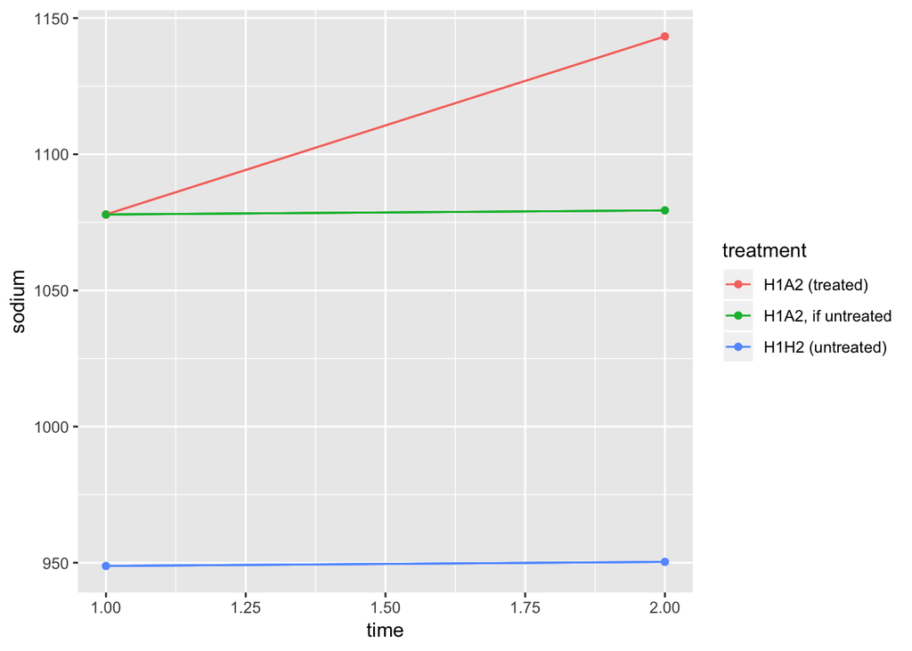

```r
away1_away2 <- person_and_meals %>%
  filter(location_type.x == 'away') %>%
    filter(location_type.y == 'away')

home1_home2 <- person_and_meals %>%
  filter(location_type.x == 'home') %>%
    filter(location_type.y == 'home')

away1_home2 <- person_and_meals %>%
  filter(location_type.x == 'away') %>%
    filter(location_type.y == 'home')

home1_away2 <- person_and_meals %>%
  filter(location_type.x == 'home') %>%
    filter(location_type.y == 'away')

time <- rep(c(1,2),3)

treatment <- c(rep("H1H2 (untreated)",2),rep("H1A2 (treated)",2),rep("H1A2, if untreated",2))

regular_did <- data.frame(time=time, sodium=c(mean(home1_home2$sodium_day1), mean(home1_home2$sodium_day2),mean(home1_away2$sodium_day1), mean(home1_away2$sodium_day2), mean(home1_away2$sodium_day1), mean(home1_home2$sodium_day2) + mean(home1_away2$sodium_day1) - mean(home1_home2$sodium_day1)),treatment=treatment)

ggplot(data=regular_did, mapping=aes(x=time,y=sodium,group=treatment,colour=treatment)) +
  geom_point() +
    geom_quantile()
```

Figure 1. “Regular” DiD, with home being the untreated state and away being the treated state.

```
## Smoothing formula not specified. Using: y ~ x
## Smoothing formula not specified. Using: y ~ x
## Smoothing formula not specified. Using: y ~ x
```

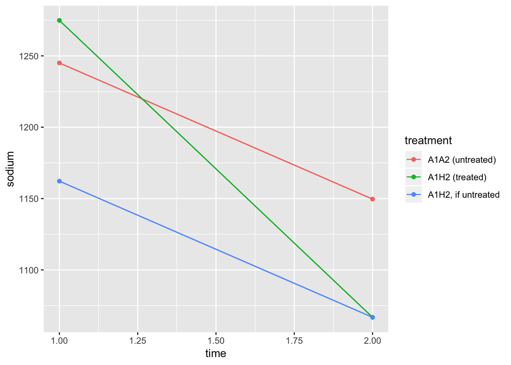

```r
time <- rep(c(2,1),3)

treatment <- c(rep("A1A2 (untreated)",2),rep("A1H2 (treated)",2),rep("A1H2, if untreated",2))
reverse_did <- data.frame(time=time, sodium=c(mean(away1_away2$sodium_day2), mean(away1_away2$sodium_day1),mean(away1_home2$sodium_day2), mean(away1_home2$sodium_day1), mean(away1_home2$sodium_day2), mean(away1_away2$sodium_day1) + mean(away1_home2$sodium_day2) - mean(away1_away2$sodium_day2)),treatment=treatment)

ggplot(data=reverse_did, mapping=aes(x=time,y=sodium,group=treatment,colour=treatment)) +
  geom_point() +
    geom_quantile()
```

Figure 2. “Reverse” DiD, with away being the untreated state and home being the treated state.

In the rest of the experiments, comparisons will be restricted to only premade or only nonpremade food, only weekends or weekdays, or a combination of these restrictions. This is done to mimic a multivariable regression, a manual version as it were, to explore the effects of these variables as well as the interactions between them. The results of Welch’s two-sample t-tests for all comparisons are shown below.

```r
# All meals (this code looks similar to that used to create the plots, but accomplishes a different purpose)

away1_away2 <- person_and_meals %>%
  filter(location_type.x == 'away') %>%
    filter(location_type.y == 'away') %>%
      ungroup() %>%
        mutate(sodium = sodium_day1 - sodium_day2) %>%
          select(sodium)

home1_home2 <- person_and_meals %>%
  filter(location_type.x == 'home') %>%
    filter(location_type.y == 'home') %>%
      ungroup() %>%
        mutate(sodium = sodium_day2 - sodium_day1) %>%
          select(sodium)

away1_home2 <- person_and_meals %>%
  filter(location_type.x == 'away') %>%
    filter(location_type.y == 'home') %>%
      ungroup() %>%
        mutate(sodium = sodium_day1 - sodium_day2) %>%
          select(sodium)

home1_away2 <- person_and_meals %>%
  filter(location_type.x == 'home') %>%
    filter(location_type.y == 'away') %>%
  ungroup() %>%
    mutate(sodium = sodium_day2 - sodium_day1) %>%
      select(sodium)

all_no_treatment <- rbind(home1_home2[1:length(home1_away2$sodium),], away1_away2)

all_treatment <- rbind(home1_away2,away1_home2[1:length(away1_away2$sodium),])

all_effect <- t.test(all_treatment$sodium,all_no_treatment$sodium)$estimate[1] - t.test(all_treatment$sodium,all_no_treatment$sodium)$estimate[2]

all_pvalue <- t.test(all_treatment$sodium,all_no_treatment$sodium)$p.value

# Only meals eaten on weekdays

person_and_meals_weekday <- person_and_meals %>%
  filter(day_type.x == 'weekday') %>%
    filter(day_type.y == 'weekday')

weekday_away1_away2 <- person_and_meals_weekday %>%
  filter(location_type.x == 'away') %>%
    filter(location_type.y == 'away') %>%
      ungroup() %>%
        mutate(sodium = sodium_day1 - sodium_day2) %>%
          select(sodium)

weekday_home1_home2 <- person_and_meals_weekday %>%
  filter(location_type.x == 'home') %>%
    filter(location_type.y == 'home') %>%
      ungroup() %>%
        mutate(sodium = sodium_day2 - sodium_day1) %>%
          select(sodium)

weekday_away1_home2 <- person_and_meals_weekday %>%
  filter(location_type.x == 'away') %>%
    filter(location_type.y == 'home') %>%
      ungroup() %>%
        mutate(sodium = sodium_day1 - sodium_day2) %>%
          select(sodium)

weekday_home1_away2 <- person_and_meals_weekday %>%
  filter(location_type.x == 'home') %>%
    filter(location_type.y == 'away') %>%
      ungroup() %>%
        mutate(sodium = sodium_day2 - sodium_day1) %>%
          select(sodium)

weekday_no_treatment <- rbind(weekday_home1_home2[1:length(weekday_home1_away2$sodium),], weekday_away1_away2[1:length(weekday_away1_home2$sodium),])

weekday_treatment <- rbind(weekday_home1_away2,weekday_away1_home2)

weekday_effect <- t.test(weekday_treatment$sodium,weekday_no_treatment$sodium)$estimate[1] - t.test(weekday_treatment$sodium,weekday_no_treatment$sodium)$estimate[2]

weekday_pvalue <- t.test(weekday_treatment$sodium,weekday_no_treatment$sodium)$p.value

# Only meals eaten on weekends

person_and_meals_weekend <- person_and_meals %>%
  filter(day_type.x == 'weekend') %>%
    filter(day_type.y == 'weekend')

weekend_away1_away2 <- person_and_meals_weekend %>%
  filter(location_type.x == 'away') %>%
    filter(location_type.y == 'away') %>%
      ungroup() %>%
        mutate(sodium = sodium_day1 - sodium_day2) %>%
          select(sodium)

weekend_home1_home2 <- person_and_meals_weekend %>%
  filter(location_type.x == 'home') %>%
    filter(location_type.y == 'home') %>%
      ungroup() %>%
        mutate(sodium = sodium_day2 - sodium_day1) %>%
          select(sodium)

weekend_away1_home2 <- person_and_meals_weekend %>%
  filter(location_type.x == 'away') %>%
    filter(location_type.y == 'home') %>%
      ungroup() %>%
        mutate(sodium = sodium_day1 - sodium_day2) %>%
          select(sodium)

weekend_home1_away2 <- person_and_meals_weekend %>%
  filter(location_type.x == 'home') %>%
    filter(location_type.y == 'away') %>%
      ungroup() %>%
        mutate(sodium = sodium_day2 - sodium_day1) %>%
          select(sodium)

weekend_no_treatment <- rbind(weekend_home1_home2[1:length(weekend_home1_away2$sodium),], weekend_away1_away2)

weekend_treatment <- rbind(weekend_home1_away2,weekend_away1_home2[1:length(weekend_away1_away2$sodium),])

weekend_effect <- t.test(weekend_treatment$sodium,weekend_no_treatment$sodium)$estimate[1] - t.test(weekend_treatment$sodium,weekend_no_treatment$sodium)$estimate[2]

weekend_pvalue <- t.test(weekend_treatment$sodium,weekend_no_treatment$sodium)$p.value

# Only premade meals

person_and_meals_premade <- person_and_meals %>%
  filter(premade.x == 'premade') %>%
    filter(premade.y == 'premade')

premade_away1_away2 <- person_and_meals_premade %>%
  filter(location_type.x == 'away') %>%
    filter(location_type.y == 'away') %>%
      ungroup() %>%
        mutate(sodium = sodium_day1 - sodium_day2) %>%
          select(sodium)

premade_home1_home2 <- person_and_meals_premade %>%
  filter(location_type.x == 'home') %>%
    filter(location_type.y == 'home') %>%
      ungroup() %>%
        mutate(sodium = sodium_day2 - sodium_day1) %>%
          select(sodium)

premade_away1_home2 <- person_and_meals_premade %>%
  filter(location_type.x == 'away') %>%
    filter(location_type.y == 'home') %>%
      ungroup() %>%
        mutate(sodium = sodium_day1 - sodium_day2) %>%
          select(sodium)

premade_home1_away2 <- person_and_meals_premade %>%
  filter(location_type.x == 'home') %>%
    filter(location_type.y == 'away') %>%
      ungroup() %>%
        mutate(sodium = sodium_day2 - sodium_day1) %>%
          select(sodium)

premade_no_treatment <- rbind(premade_home1_home2[1:length(premade_home1_away2$sodium),], premade_away1_away2[1:length(premade_away1_home2$sodium),])

premade_treatment <- rbind(premade_home1_away2,premade_away1_home2)

premade_effect <- t.test(premade_treatment$sodium,premade_no_treatment$sodium)$estimate[1] - t.test(premade_treatment$sodium,premade_no_treatment$sodium)$estimate[2]

premade_pvalue <- t.test(premade_treatment$sodium,premade_no_treatment$sodium)$p.value
```

```r
# Only non-premade meals

person_and_meals_notpremade <- person_and_meals %>%
  filter(premade.x == 'not premade') %>%
  filter(premade.y == 'not premade')

notpremade_away1_away2 <- person_and_meals_notpremade %>%
  filter(location_type.x == 'away') %>%
    filter(location_type.y == 'away') %>%
      ungroup() %>%
        mutate(sodium = sodium_day1 - sodium_day2) %>%
          select(sodium)

notpremade_home1_home2 <- person_and_meals_notpremade %>%
  filter(location_type.x == 'home') %>%
    filter(location_type.y == 'home') %>%
      ungroup() %>%
        mutate(sodium = sodium_day2 - sodium_day1) %>%
          select(sodium)

notpremade_away1_home2 <- person_and_meals_notpremade %>%
  filter(location_type.x == 'away') %>%
    filter(location_type.y == 'home') %>%
      ungroup() %>%
        mutate(sodium = sodium_day1 - sodium_day2) %>%
          select(sodium)

notpremade_home1_away2 <- person_and_meals_notpremade %>%
  filter(location_type.x == 'home') %>%
    filter(location_type.y == 'away') %>%
      ungroup() %>%
        mutate(sodium = sodium_day2 - sodium_day1) %>%
          select(sodium)

notpremade_no_treatment <- rbind(notpremade_home1_home2[1:length(notpremade_home1_away2$sodium),], notpremade_away1_away2)

notpremade_treatment <- rbind(notpremade_home1_away2,notpremade_away1_home2[1:length(notpremade_away1_away2$sodium),])

notpremade_effect <- t.test(notpremade_treatment$sodium,notpremade_no_treatment$sodium)$estimate[1] - t.test(notpremade_treatment$sodium,notpremade_no_treatment$sodium)$estimate[2]

notpremade_pvalue <- t.test(notpremade_treatment$sodium,notpremade_no_treatment$sodium)$p.value

# Only meals premade on a weekday

person_and_meals_premade_weekday <- person_and_meals_weekday %>%
  filter(premade.x == 'premade') %>%
    filter(premade.y == 'premade')

premade_weekday_away1_away2 <- person_and_meals_premade_weekday %>%
  filter(location_type.x == 'away') %>%
    filter(location_type.y == 'away') %>%
      ungroup() %>%
        mutate(sodium = sodium_day1 - sodium_day2) %>%
          select(sodium)

premade_weekday_home1_home2 <- person_and_meals_premade_weekday %>%
  filter(location_type.x == 'home') %>%
    filter(location_type.y == 'home') %>%
      ungroup() %>%
        mutate(sodium = sodium_day2 - sodium_day1) %>%
          select(sodium)

premade_weekday_away1_home2 <- person_and_meals_premade_weekday %>%
  filter(location_type.x == 'away') %>%
    filter(location_type.y == 'home') %>%
      ungroup() %>%
        mutate(sodium = sodium_day1 - sodium_day2) %>%
          select(sodium)

premade_weekday_home1_away2 <- person_and_meals_premade_weekday %>%
  filter(location_type.x == 'home') %>%
    filter(location_type.y == 'away') %>%
    ungroup() %>%
      mutate(sodium = sodium_day2 - sodium_day1) %>%
        select(sodium)

premade_weekday_no_treatment <- rbind(premade_weekday_home1_home2[1:length(premade_weekday_home1_away2$sodium),], premade_weekday_away1_away2[1:length(premade_weekday_away1_home2$sodium),])

premade_weekday_treatment <- rbind(premade_weekday_home1_away2,premade_weekday_away1_home2)

premade_weekday_effect <- t.test(premade_weekday_treatment$sodium,premade_weekday_no_treatment$sodium)$estimate[1] - t.test(premade_weekday_treatment$sodium,premade_weekday_no_treatment$sodium)$estimate[2]

premade_weekday_pvalue <- t.test(premade_weekday_treatment$sodium, premade_weekday_no_treatment$sodium)$p.value

# Only non-premade meals eaten on weekdays

person_and_meals_notpremade_weekday <- person_and_meals_weekday %>%
  filter(premade.x == 'not premade') %>%
    filter(premade.y == 'not premade')

notpremade_weekday_away1_away2 <- person_and_meals_notpremade_weekday %>%
  filter(location_type.x == 'away') %>%
    filter(location_type.y == 'away') %>%
      ungroup() %>%
        mutate(sodium = sodium_day1 - sodium_day2) %>%
          select(sodium)

notpremade_weekday_home1_home2 <- person_and_meals_notpremade_weekday %>%
  filter(location_type.x == 'home') %>%
    filter(location_type.y == 'home') %>%
      ungroup() %>%
        mutate(sodium = sodium_day2 - sodium_day1) %>%
          select(sodium)

notpremade_weekday_away1_home2 <- person_and_meals_notpremade_weekday %>%
  filter(location_type.x == 'away') %>%
    filter(location_type.y == 'home') %>%
      ungroup() %>%
        mutate(sodium = sodium_day1 - sodium_day2) %>%
          select(sodium)

notpremade_weekday_home1_away2 <- person_and_meals_notpremade_weekday %>%
  filter(location_type.x == 'home') %>%
    filter(location_type.y == 'away') %>%
      ungroup() %>%
        mutate(sodium = sodium_day2 - sodium_day1) %>%
  select(sodium)

notpremade_weekday_no_treatment <- rbind(notpremade_weekday_home1_home2[1:length(notpremade_weekday_home1_away2$sodium),], notpremade_weekday_away1_away2[1:length(notpremade_weekday_away1_home2$sodium),])

notpremade_weekday_treatment <- rbind(notpremade_weekday_home1_away2,notpremade_weekday_away1_home2)

notpremade_weekday_effect <- t.test(notpremade_weekday_treatment$sodium,notpremade_weekday_no_treatment$sodium)$estimate[1] - t.test(notpremade_weekday_treatment$sodium,notpremade_weekday_no_treatment$sodium)$estimate[2]

notpremade_weekday_pvalue <- t.test(notpremade_weekday_treatment$sodium, notpremade_weekday_no_treatment$sodium)$p.value


# Only premade meals eaten on weekends

person_and_meals_premade_weekend <- person_and_meals_weekend %>%
  filter(premade.x == 'premade') %>%
    filter(premade.y == 'premade')

premade_weekend_away1_away2 <- person_and_meals_premade_weekend %>%
  filter(location_type.x == 'away') %>%
    filter(location_type.y == 'away') %>%
      ungroup() %>%
        mutate(sodium = sodium_day1 - sodium_day2) %>%
          select(sodium)

premade_weekend_home1_home2 <- person_and_meals_premade_weekend %>%
  filter(location_type.x == 'home') %>%
    filter(location_type.y == 'home') %>%
      ungroup() %>%
        mutate(sodium = sodium_day2 - sodium_day1) %>%
          select(sodium)

premade_weekend_away1_home2 <- person_and_meals_premade_weekend %>%
  filter(location_type.x == 'away') %>%
    filter(location_type.y == 'home') %>%
      ungroup() %>%
        mutate(sodium = sodium_day1 - sodium_day2) %>%
          select(sodium)
```

```r
premade_weekend_home1_away2 <- person_and_meals_premade_weekend %>%
  filter(location_type.x == 'home') %>%
    filter(location_type.y == 'away') %>%
      ungroup() %>%
        mutate(sodium = sodium_day2 - sodium_day1) %>%
          select(sodium)

premade_weekend_no_treatment <- rbind(premade_weekend_home1_home2[1:length(premade_weekend_home1_away2$sodium),], premade_weekend_away1_away2)

premade_weekend_treatment <- rbind(premade_weekend_home1_away2,premade_weekend_away1_home2[1:length(premade_weekend_away1_away2$sodium),])

premade_weekend_effect <- t.test(premade_weekend_treatment$sodium,premade_weekend_no_treatment$sodium)$estimate[1] - t.test(premade_weekend_treatment$sodium,premade_weekend_no_treatment$sodium)$estimate[2]

premade_weekend_pvalue <- t.test(premade_weekend_treatment$sodium, premade_weekend_no_treatment$sodium)$p.value

# Only non-premade meals eaten on weekends

person_and_meals_notpremade_weekend <- person_and_meals_weekend %>%
  filter(premade.x == 'not premade') %>%
    filter(premade.y == 'not premade')

notpremade_weekend_away1_away2 <- person_and_meals_notpremade_weekend %>%
  filter(location_type.x == 'away') %>%
    filter(location_type.y == 'away') %>%
      ungroup() %>%
        mutate(sodium = sodium_day1 - sodium_day2) %>%
          select(sodium)

notpremade_weekend_home1_home2 <- person_and_meals_notpremade_weekend %>%
  filter(location_type.x == 'home') %>%
    filter(location_type.y == 'home') %>%
      ungroup() %>%
        mutate(sodium = sodium_day2 - sodium_day1) %>%
          select(sodium)

notpremade_weekend_away1_home2 <- person_and_meals_notpremade_weekend %>%
  filter(location_type.x == 'away') %>%
    filter(location_type.y == 'home') %>%
      ungroup() %>%
        mutate(sodium = sodium_day1 - sodium_day2) %>%
          select(sodium)

notpremade_weekend_home1_away2 <- person_and_meals_notpremade_weekend %>%
  filter(location_type.x == 'home') %>%
    filter(location_type.y == 'away') %>%
      ungroup() %>%
        mutate(sodium = sodium_day2 - sodium_day1) %>%
          select(sodium)

notpremade_weekend_no_treatment <- rbind(notpremade_weekend_home1_home2[1:length(notpremade_weekend_home1_away2$sodium),], notpremade_weekend_away1_away2)

notpremade_weekend_treatment <- rbind(notpremade_weekend_home1_away2, notpremade_weekday_away1_home2[1:length(notpremade_weekend_away1_away2$sodium),])

notpremade_weekend_effect <- t.test(notpremade_weekend_treatment$sodium, notpremade_weekend_no_treatment$sodium)$estimate[1] - t.test(notpremade_weekend_treatment$sodium, notpremade_weekend_no_treatment$sodium)$estimate[2]

notpremade_weekend_pvalue <- t.test(notpremade_weekend_treatment$sodium, notpremade_weekend_no_treatment$sodium)$p.value

# T-test results organized in a dataframe

ttest.df <- data.frame("day_type" = c("either", "weekday", "weekend", "either", "either", "weekday", "weekday", "weekend", "weekend"), "premade_status" = c("either", "either", "either", "premade", "not premade", "premade", "not premade", "premade", "not premade"), "effect" = c(all_effect, weekday_effect, weekend_effect, premade_effect, notpremade_effect, premade_weekday_effect, notpremade_weekday_effect, premade_weekend_effect, notpremade_weekend_effect), "p-value" = c(all_pvalue, weekday_pvalue, weekend_pvalue, premade_pvalue, notpremade_pvalue, premade_weekday_pvalue, notpremade_weekday_pvalue, premade_weekend_pvalue, notpremade_weekend_pvalue))

print(ttest.df)
```

```
##   day_type premade_status     effect      p.value
## 1   either         either   97.80213 0.0018260922
## 2  weekday         either  169.16015 0.0002059149
## 3  weekend         either -318.74074 0.0591661339
## 4   either        premade   20.66396 0.7592821889
## 5   either    not premade -133.63651 0.0090904723
## 6  weekday        premade  104.54008 0.3466184972
## 7  weekday    not premade  -66.31429 0.3443056681
## 8  weekend        premade  -52.87500 0.8654871261
## 9  weekend    not premade -644.05882 0.0501562456
```

### Next steps

This study could be extended in various directions. Firstly, greater sample sizes (and therefore more definite effect sizes) could be obtained by using NHANES data from years other than 2015-2016. Secondly, other nutrients could be studied such as calories and sugar as part of an investigation into ways to combat obesity. Thirdly, further interaction effects could be isolated such as BMI, income, education level, and potassium intake (for example, if the high sodium gains from eating out occurred only in individuals with high dietary potassium, this effect would not need to be addressed as much because potassium can counteract the effect of sodium on the body). This demographic information as well as information about these other nutrients is already included in the publicly available portions of the NHANES dataset. Lastly, sensitivity analyses could be conducted in order to determine how sensitive the results to the accuracy of the self-reported food intakes, because of several biases that could have impacted this data such as forgetfulness of the participants as well as shame from eating more food or less healthy food than is perceived as normal.

### Acknowledgements

The author thanks Dr. Konrad Kording for his causality course that taught the Differences-in-Differences method, Dr. Marilyn Schapira for her insights into the biases that often impact survey-based research, and the USDA and CDC for jointly sponsoring the dietary component of NHANES.